# phase2

MohammadMehdi zare 98100431

2/16/2022

#install packages

```r
library(readr)
library(ggplot2)
library(dplyr)
library(ggthemes)
library(tidyr)
library(patchwork)
library(rjson)
library(geosphere)
library(data.table)
```

## read dataframe

```r
df=read.csv("lyon_housing.csv")

metro_df=fromJSON(file = "data/station_coordinates.json")
i=0
lat=vector()
lon=vector()
names=vector()
for (variable in metro_df) {
  for (v in variable) {
    for (x in v) {
         if (i%%3==0) {
            names=c(names,x)
         }
         if (i%%3==1) {
            lat=c(lat,x)
         }
         if (i%%3==2) {
            lon=c(lon,x)
         }

    }
      i=i+1
  }
}

metro_df=data.frame(names,lat,lon)


# View(df)
```

# part EDA

```r
# sum(is.na(df$latitudel))
df %>% summarise_all(~ sum(is.na(.)))
```

```
##   date_transaction type_purchase type_property rooms_count surface_housing
## 1                0             0             0           0               0
##   surface_effective_usable surface_terrain parkings_count price address
## 1                    14491               0              0     0       0
##   district latitude longitude date_construction
## 1        0      143       143                 0
```

```r
clean_df=df[!is.na(df$latitude),]
# View(clean_df)





clean_df=mutate(clean_df,price_surface=clean_df$price/clean_df$surface_housing,price_room=clean_df$price/clean_df$rooms_count)


dis_f_metro=vector()
for (home in 1:length(clean_df$latitude)){
  lat1 = clean_df[home,12]
  lon1 = clean_df[home,13]
  dis_from_metro = distm(c(lon1, lat1), cbind(metro_df$lon, metro_df$lat), fun = distHaversine)
  min_dis_from_metro = min(dis_from_metro)
  dis_f_metro = c(dis_f_metro, min_dis_from_metro)
}
clean_df=mutate(clean_df,dis_from_metro=dis_f_metro)


# View(clean_df)
```

برای هر ستون تعداد داده های گم شده را پیدا میکنیم و مشاهدع میکنیم که فقط ستون های  
surface_effective_usable و latitude و longitude و هستند که مقادیر NA دارند . حال برای پاک سازی دیتا ها ، خانه هایی که مختصات ندارند را حذف میکنیم . دو ستون را که فکر میکردم بکار بیایند را اضافه میکنم که عبارت هستند از قیمت برحسب مساحت و قیمت بر حسب تعداد اتاق.

همچنین در پایین میتوانیم یک خلاصه از تمام ستون ها ببینیم که نوع مقادیر ان و اینکه چه مقادیری میگرند را میتوانیم ببینیم. دو ستون  
type_purchaseوtype_property و چون فقط دو مقدار میگیرند را تبدیل به فاکتور میکنیم و تعداد خانه های از نوع انهارا میتوانیم در زیر مشاهده کنیم . همچنین ستون هایی که مقادیر عددی دارند هم میتوانیم مینیمم و ماکسیمم و میانه و میانگین و چارک اول و سوم را ببینیم .

```r
clean_df$type_purchase=as.factor(clean_df$type_purchase)
clean_df$type_property=as.factor(clean_df$type_property)
summary(clean_df)
```

```
##  date_transaction   type_purchase      type_property    rooms_count
##  Length:40373       ancien:35419   appartement:39700   Min.   :1.000
##  Class :character   VEFA  : 4954   maison     :  673   1st Qu.:2.000
##  Mode  :character                                      Median :3.000
##                                                        Mean   :2.792
##                                                        3rd Qu.:4.000
##                                                        Max.   :6.000
##
##  surface_housing  surface_effective_usable surface_terrain   parkings_count
##  Min.   : 20.00   Min.   :  2.81           Min.   :  0.000   Min.   :0.0000
##  1st Qu.: 45.00   1st Qu.: 44.69           1st Qu.:  0.000   1st Qu.:0.0000
##  Median : 63.00   Median : 62.80           Median :  0.000   Median :1.0000
##  Mean   : 65.22   Mean   : 63.51           Mean   :  3.713   Mean   :0.5988
##  3rd Qu.: 80.00   3rd Qu.: 78.09           3rd Qu.:  0.000   3rd Qu.:1.0000
##  Max.   :300.00   Max.   :270.67           Max.   :944.000   Max.   :3.0000
##                   NA's   :14435
##      price           address            district            latitude
##  Min.   :  24000   Length:40373       Length:40373       Min.   :45.72
##  1st Qu.: 155400   Class :character   Class :character   1st Qu.:45.75
##  Median : 220000   Mode  :character   Mode  :character   Median :45.76
##  Mean   : 255835                                         Mean   :45.76
##  3rd Qu.: 309000                                         3rd Qu.:45.77
##  Max.   :2780000                                         Max.   :45.81
##
##    longitude     date_construction  price_surface     price_room
##  Min.   :4.773   Length:40373       Min.   : 1000   Min.   : 15000
##  1st Qu.:4.831   Class :character   1st Qu.: 2986   1st Qu.: 66667
##  Median :4.854   Mode  :character   Median : 3854   Median : 90463
##  Mean   :4.852                      Mean   : 3966   Mean   : 97589
##  3rd Qu.:4.876                      3rd Qu.: 4839   3rd Qu.:118650
##  Max.   :4.920                      Max.   :34750   Max.   :835000
##
##  dis_from_metro
##  Min.   :  16.23
##  1st Qu.: 223.19
##  Median : 356.24
##  Mean   : 478.77
##  3rd Qu.: 565.89
##  Max.   :3049.35
##
```

حالا هیستوگرام ستون های عددی را نشان میدهیم و از این میفهمیم که فراوانی داده ها چه توزیعی دارد یا به عبارت دیگر داده ها چگونه بر حسب اون پارامتر پراکنده هستند

همچنین ممتوجه داده های پرت موجود میشویم . مثلا در ستون surface_terrain میبینیم که هستوگرام به خاطر داده پرت خراب شده است یا در قیمت خانه ها یک خانه بسیار گران قیمت وجود دارد

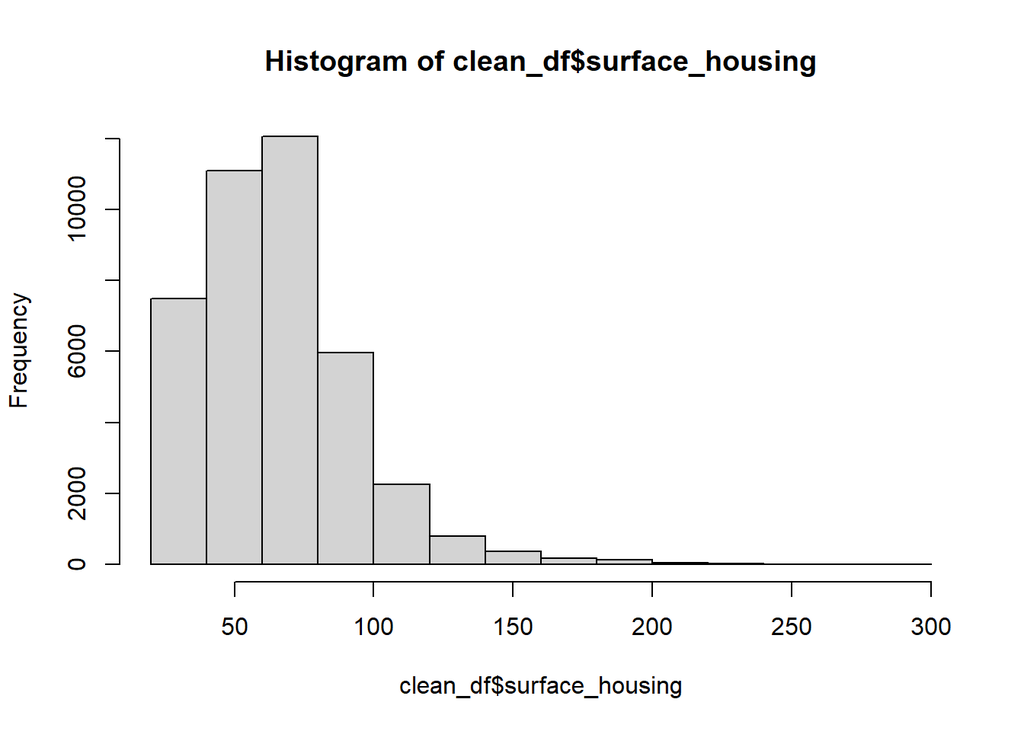

```r
hist(clean_df$surface_housing)
```

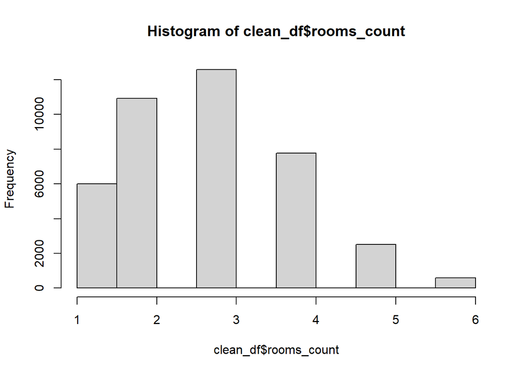

```r
hist(clean_df$rooms_count)
```

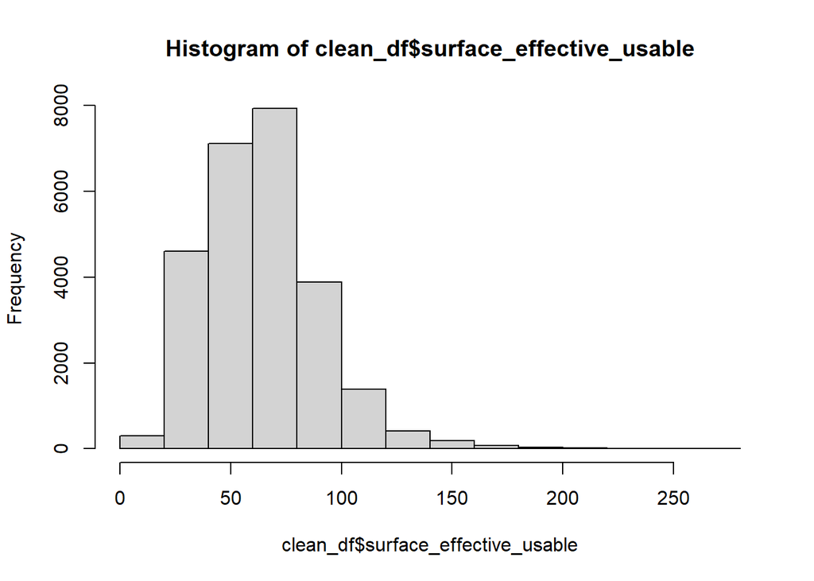

```r
hist(clean_df$surface_effective_usable)
```

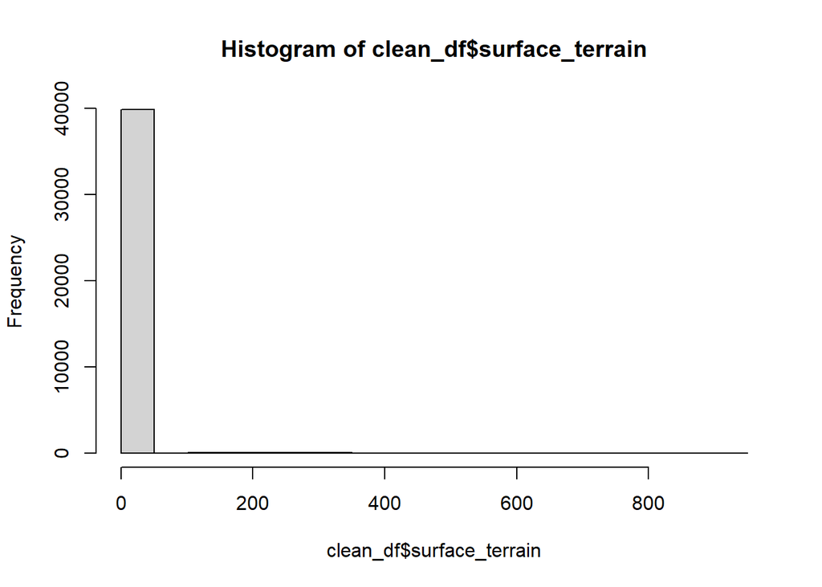

```r
hist(clean_df$surface_terrain)
```

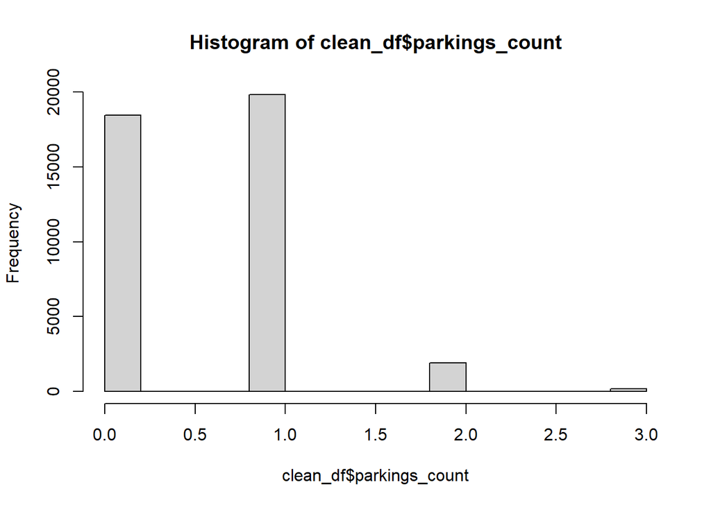

```r
hist(clean_df$parkings_count)
```

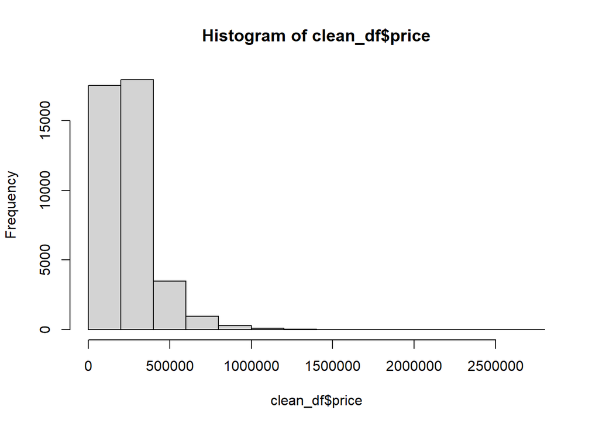

```r
hist(clean_df$price)
```

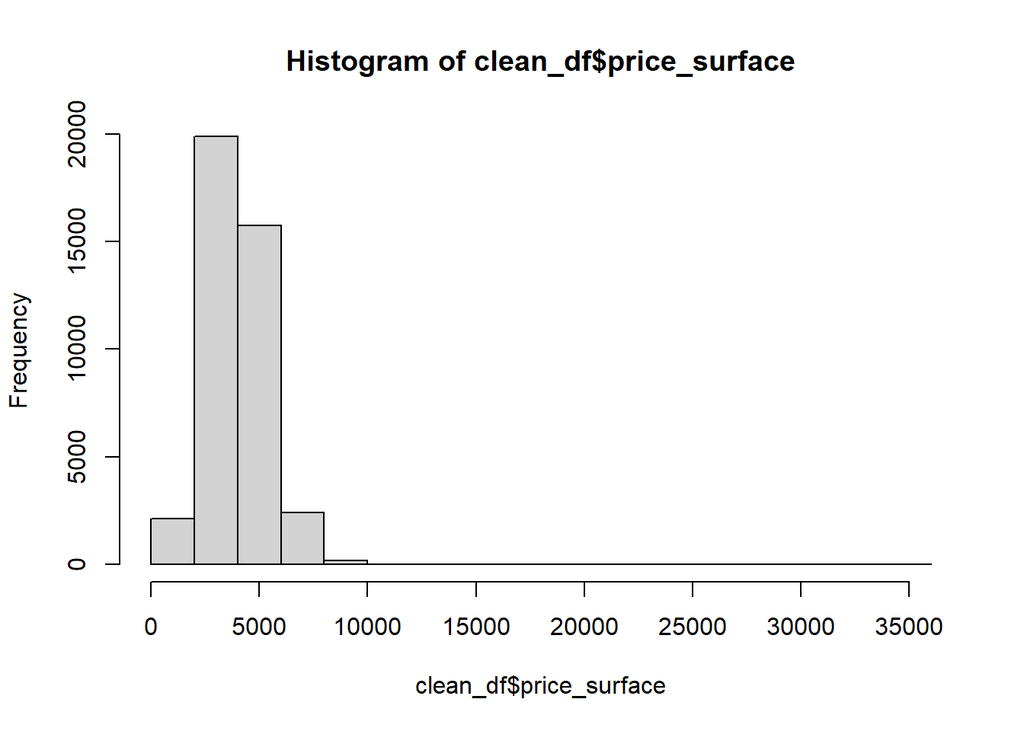

```r
hist(clean_df$price_surface)
```

حالا میخواهیم ارتباط ستون های مختلف یا یکدیگر را بررسی کنیم برای همین از ستون های مختلف بر حسب هم رگرسون خطی حساب میکنیم و نمودار انهارا بر حسب هم نشان میدهیم .

```r
surface_price_reg=lm(clean_df$price~clean_df$surface_housing)
summary(surface_price_reg)
```

```
##
## Call:
## lm(formula = clean_df$price ~ clean_df$surface_housing)
##
## Residuals:
##     Min      1Q  Median      3Q     Max
## -852973  -57388   -1768   50073 2463692
##
## Coefficients:
##                           Estimate Std. Error t value Pr(>|t|)
## (Intercept)              -11056.18    1285.94  -8.598   <2e-16 ***
## clean_df$surface_housing   4092.05      18.09 226.146   <2e-16 ***
## ---
## Signif. codes:  0 '***' 0.001 '**' 0.01 '*' 0.05 '.' 0.1 ' ' 1
##
## Residual standard error: 102600 on 40371 degrees of freedom
## Multiple R-squared:  0.5588, Adjusted R-squared:  0.5588
## F-statistic: 5.114e+04 on 1 and 40371 DF,  p-value: < 2.2e-16
```

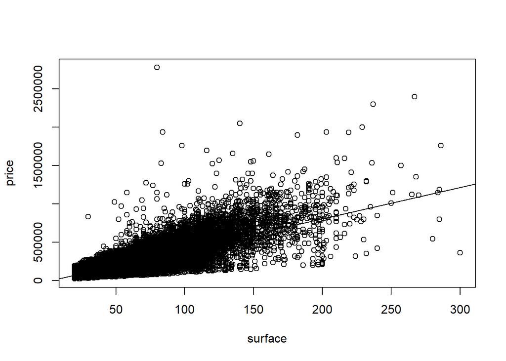

```r
plot(x=clean_df$surface_housing,y=clean_df$price,xlab = "surface",ylab = "price")
abline(surface_price_reg)
```

با توجه به نمودار بالا وضذیب های رگرسون و مقدار R میتوان دید که رابطه خطی ای بین قیمت ومساحت است

```r
surface_room_reg=lm(clean_df$rooms_count~clean_df$surface_housing)
summary(surface_room_reg)
```

```
##
## Call:
## lm(formula = clean_df$rooms_count ~ clean_df$surface_housing)
##
## Residuals:
##     Min      1Q  Median      3Q     Max
## -8.0233 -0.3632  0.0224  0.3913  3.0407
##
## Coefficients:
##                           Estimate Std. Error t value Pr(>|t|)
## (Intercept)              0.5049851  0.0080618   62.64   <2e-16 ***
## clean_df$surface_housing 0.0350612  0.0001134  309.07   <2e-16 ***
## ---
## Signif. codes:  0 '***' 0.001 '**' 0.01 '*' 0.05 '.' 0.1 ' ' 1
##
## Residual standard error: 0.6433 on 40371 degrees of freedom
## Multiple R-squared:  0.7029, Adjusted R-squared:  0.7029
## F-statistic: 9.553e+04 on 1 and 40371 DF,  p-value: < 2.2e-16
```

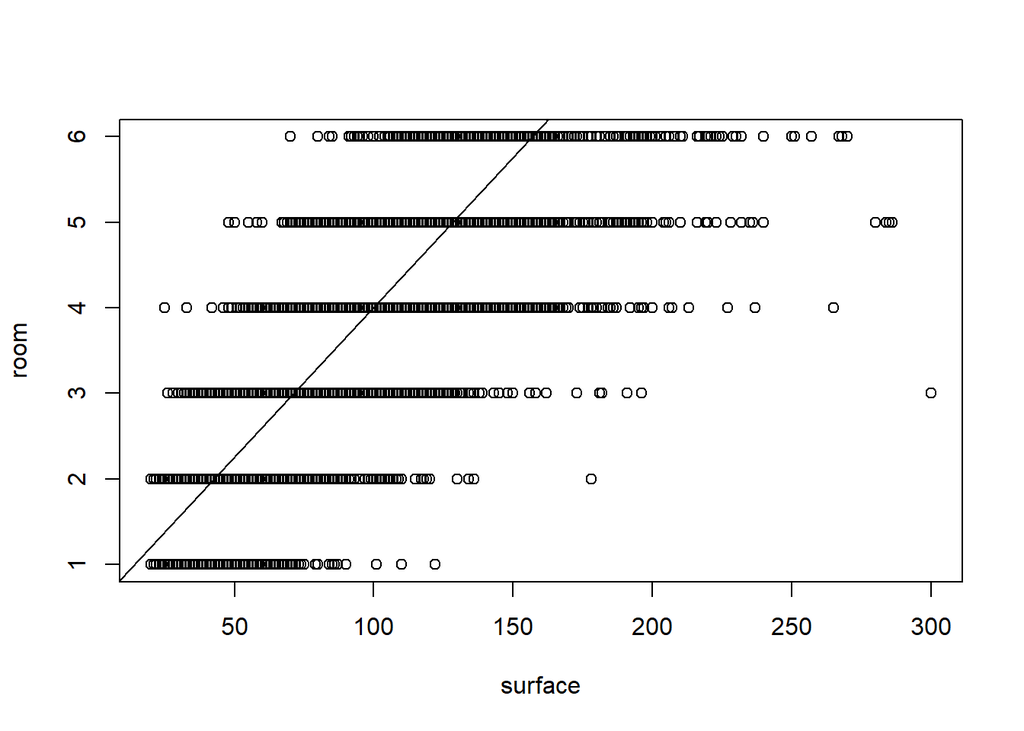

```r
plot(x=clean_df$surface_housing,y=clean_df$rooms_count,xlab = "surface",ylab = "room")
abline(surface_room_reg)
```

همچینین با توجه به نمودار بالا وضرایب رگرسون و مقدار R میتوان دید که رابطه خطی ای بین تعداد اتاق ومساحت برقارار است

```r
room_price_reg=lm(clean_df$price~clean_df$rooms_count)
summary(room_price_reg)
```

```
##
## Call:
## lm(formula = clean_df$price ~ clean_df$rooms_count)
##
## Residuals:
##     Min      1Q  Median      3Q     Max
## -377744  -69019  -12019   46879 2436073
##
## Coefficients:
##                      Estimate Std. Error t value Pr(>|t|)
## (Intercept)             52294       1640   31.89   <2e-16 ***
## clean_df$rooms_count    72908        541  134.75   <2e-16 ***
## ---
## Signif. codes:  0 '***' 0.001 '**' 0.01 '*' 0.05 '.' 0.1 ' ' 1
##
## Residual standard error: 128300 on 40371 degrees of freedom
## Multiple R-squared:  0.3102, Adjusted R-squared:  0.3102
## F-statistic: 1.816e+04 on 1 and 40371 DF,  p-value: < 2.2e-16
```

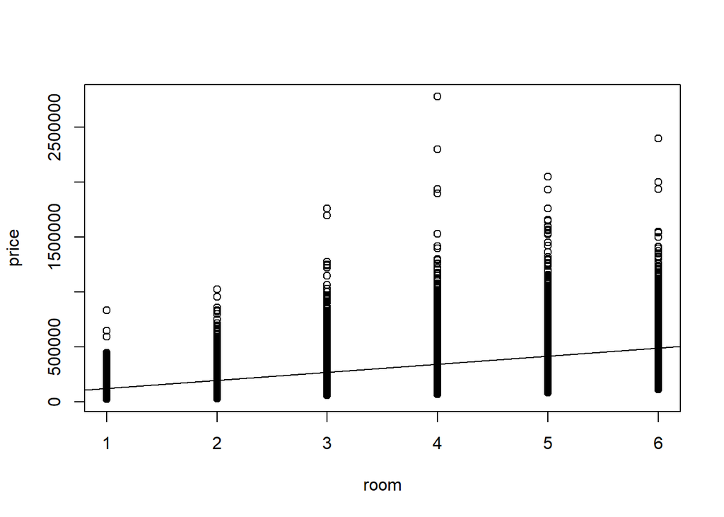

```r
plot(x=clean_df$rooms_count,y=clean_df$price,xlab = "room",ylab = "price")
abline(room_price_reg)
```

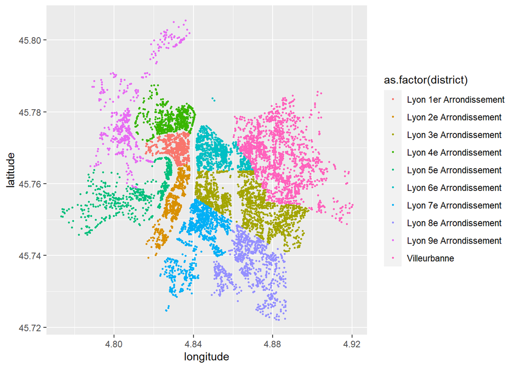

```r
(ggplot() +geom_point( data=clean_df, aes(y=latitude, x=longitude,color = as.factor(district)),size=.5 ))
```

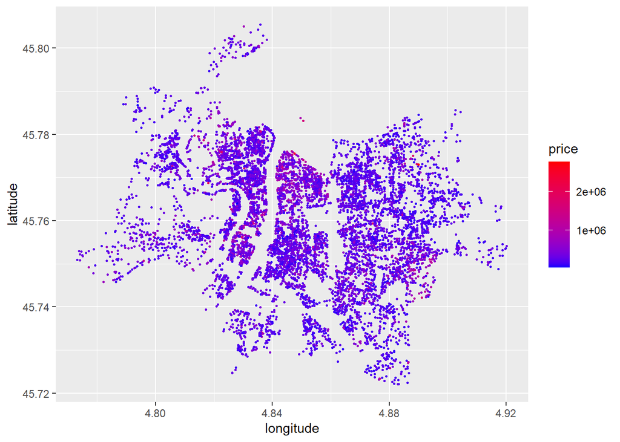

```r
 ( ggplot() +geom_point( data=clean_df, aes(y=latitude, x=longitude,color = price),size=.5 )+scale_color_gradient(low = 'blue', high = 'red'))
```

با توجه به نقشه های بالا میتوان نتیجه گرفت که مناطق مرکزی از قیمت بیشتری برخودار هستند

# part 2 - Inference & Visualization

```r
appartement_df=filter(clean_df,clean_df$type_property=="appartement")
maison_df=filter(clean_df,clean_df$type_property=="maison")

t.test(maison_df$surface_housing ,appartement_df$surface_housing  )
```

```
##
##  Welch Two Sample t-test
##
## data:  maison_df$surface_housing and appartement_df$surface_housing
## t = 25.493, df = 682.7, p-value < 2.2e-16
## alternative hypothesis: true difference in means is not equal to 0
## 95 percent confidence interval:
##  36.61301 42.72343
## sample estimates:
## mean of x mean of y
##  104.2288   64.5606
```

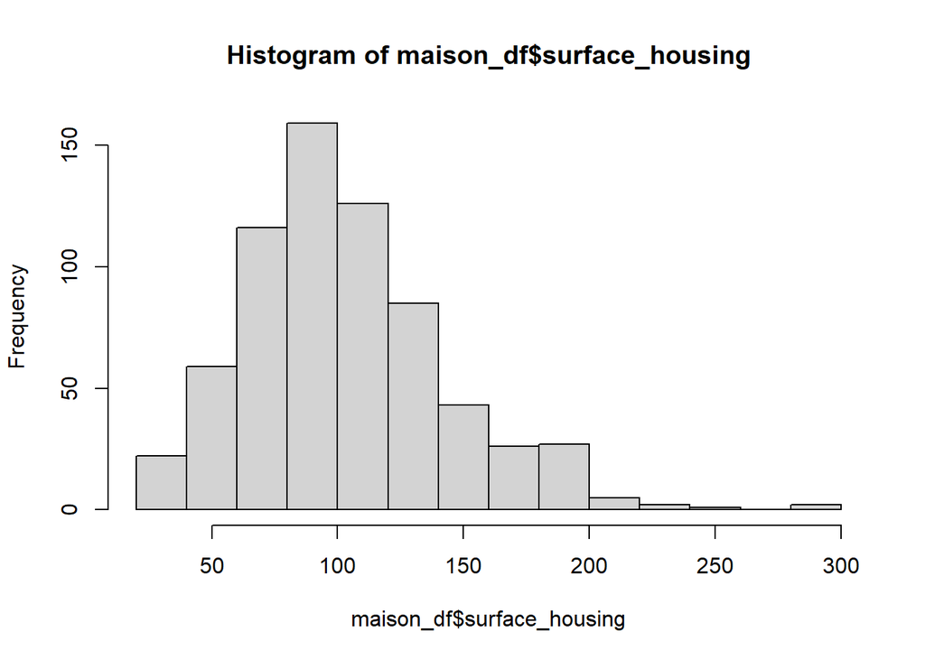

```r
hist(maison_df$surface_housing)
```

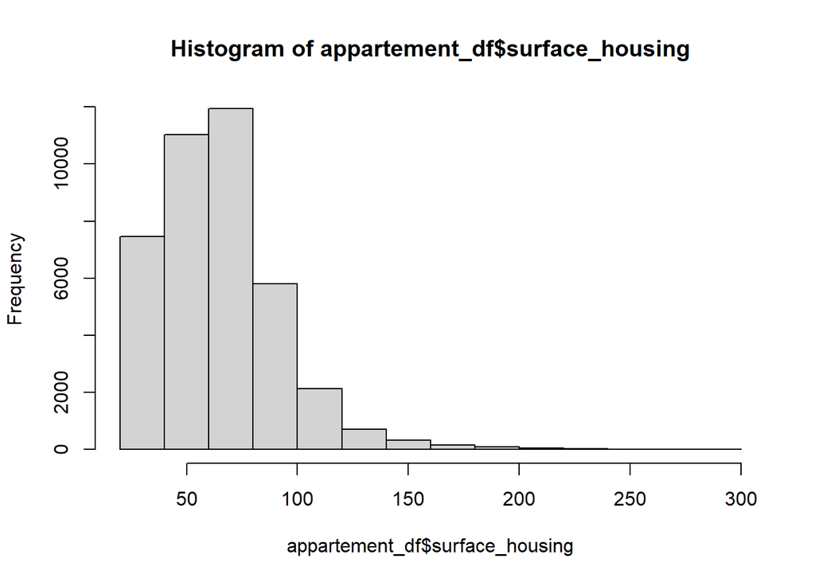

```r
hist(appartement_df$surface_housing)
```

اگر فرض صفر را مبنی بر برابر بودن مساحت خانه و اپارتمان بگیریم و تی تست را انجلم دهیم ، میبینم که با توجه به کم بودن p_value این فرض رد میشود. به این معنا که مساحت این دو با هم برابر نیستندو به عبارتی ارتباط نداردن

```r
price_metro_reg=lm(clean_df$price~clean_df$dis_from_metro)
plot(y=clean_df$price, x=clean_df$dis_from_metro)
summary(price_metro_reg)
```

```
##
## Call:
## lm(formula = clean_df$price ~ clean_df$dis_from_metro)
##
## Residuals:
##     Min      1Q  Median      3Q     Max
## -237783  -99947  -35258   52276 2526123
##
## Coefficients:
##                           Estimate Std. Error t value Pr(>|t|)
## (Intercept)             264261.107   1159.468   227.9   <2e-16 ***
## clean_df$dis_from_metro    -17.599      1.814    -9.7   <2e-16 ***
## ---
## Signif. codes:  0 '***' 0.001 '**' 0.01 '*' 0.05 '.' 0.1 ' ' 1
##
## Residual standard error: 154300 on 40371 degrees of freedom
## Multiple R-squared:  0.002325,   Adjusted R-squared:  0.002301
## F-statistic:  94.1 on 1 and 40371 DF,  p-value: < 2.2e-16
```

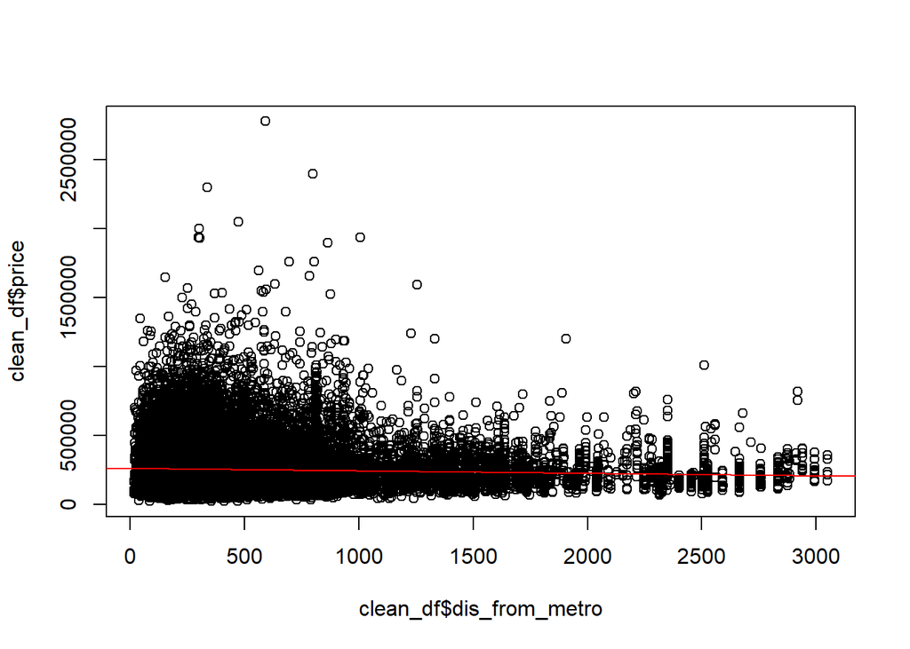

```r
abline(price_metro_reg,col="red")
```

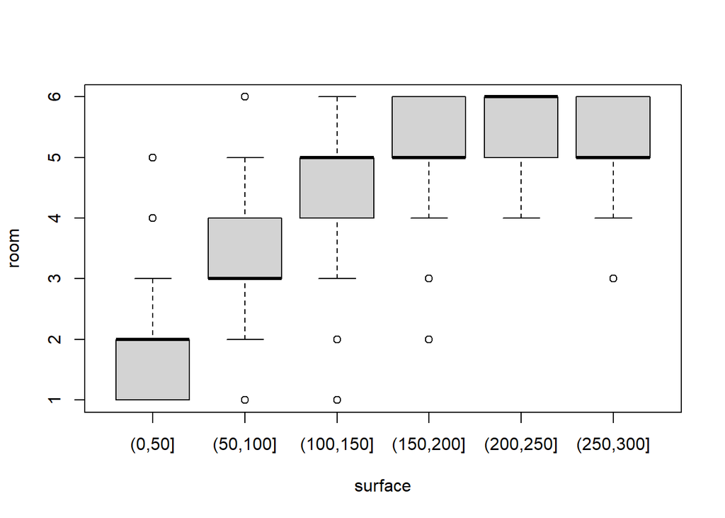

```r
boxplot(data=clean_df,clean_df$rooms_count~cut(clean_df$surface_housing,pretty(clean_df$surface_housing)),xlab = "surface", ylab = "room")
```

از نمودار جعبه ای بالا میتوان فهمید که هر چه مساحت خانه بیشتر باشد ، تعداد اتاق های بیشتری دارد ولی از جایی به بعد دیگر تعداد اتاق ها بیشتر نشده و همچنین در خانه هایی با مساحت بین ۵۰ تا ۱۵۰ بیشترین تنوع در تعداد اتاق را داریم

```r
df1=filter(clean_df,clean_df$district=="Villeurbanne")
tdf1=aggregate(df1[,9],list(substr(as.character(df1$date_transaction),1,4)),mean)



df2=filter(clean_df,clean_df$district=="Lyon 1er Arrondissement")
df3=filter(clean_df,clean_df$district=="Lyon 2e Arrondissement")
df4=filter(clean_df,clean_df$district=="Lyon 3e Arrondissement")
df5=filter(clean_df,clean_df$district=="Lyon 4e Arrondissement")
df6=filter(clean_df,clean_df$district=="Lyon 5e Arrondissement")
df7=filter(clean_df,clean_df$district=="Lyon 6e Arrondissement")
df8=filter(clean_df,clean_df$district=="Lyon 7e Arrondissement")
df9=filter(clean_df,clean_df$district=="Lyon 8e Arrondissement")
df10=filter(clean_df,clean_df$district=="Lyon 9e Arrondissement")


tdf2=aggregate(df2[,9],list(substr(as.character(df2$date_transaction),1,4)),mean)
tdf3=aggregate(df3[,9],list(substr(as.character(df3$date_transaction),1,4)),mean)
tdf4=aggregate(df4[,9],list(substr(as.character(df4$date_transaction),1,4)),mean)
tdf5=aggregate(df5[,9],list(substr(as.character(df5$date_transaction),1,4)),mean)
tdf6=aggregate(df6[,9],list(substr(as.character(df6$date_transaction),1,4)),mean)
tdf7=aggregate(df7[,9],list(substr(as.character(df7$date_transaction),1,4)),mean)
tdf8=aggregate(df8[,9],list(substr(as.character(df8$date_transaction),1,4)),mean)
tdf9=aggregate(df9[,9],list(substr(as.character(df9$date_transaction),1,4)),mean)
tdf10=aggregate(df10[,9],list(substr(as.character(df10$date_transaction),1,4)),mean)
```

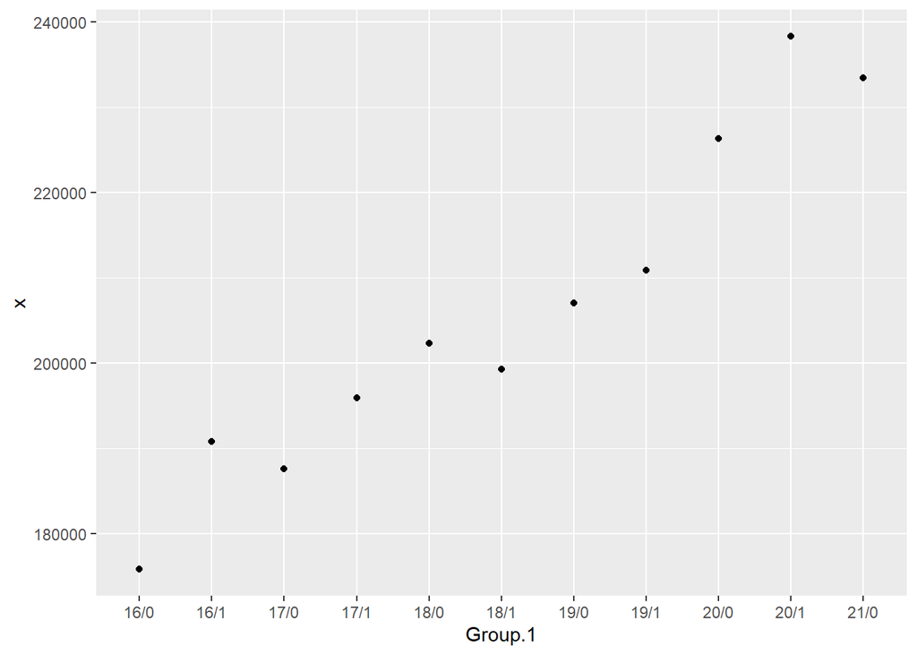

```r
ggplot(data = tdf1,aes(y=x,x=Group.1))+geom_point()
```

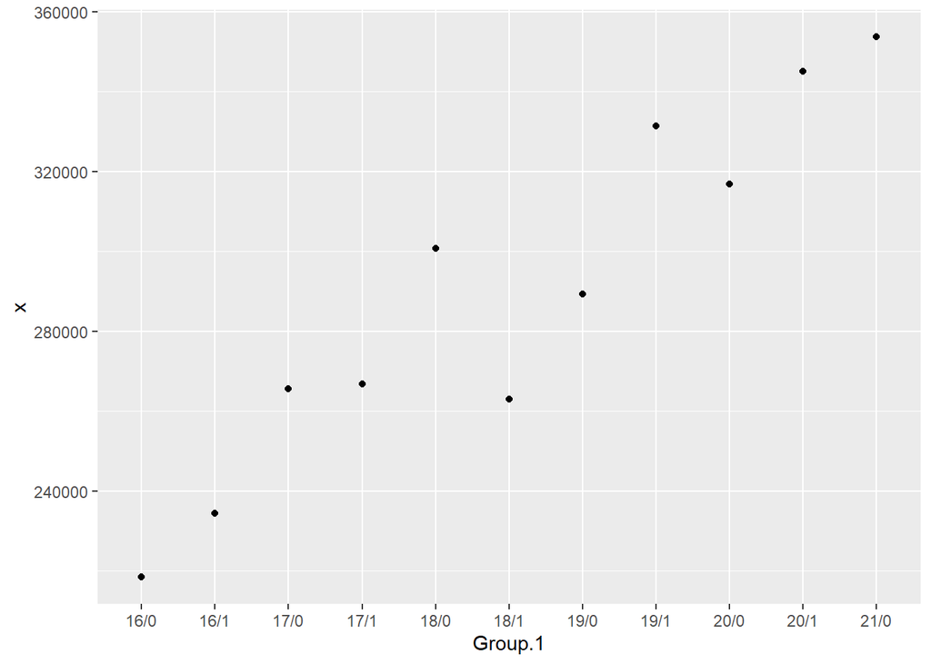

```r
ggplot(data = tdf2,aes(y=x,x=Group.1))+geom_point()
```

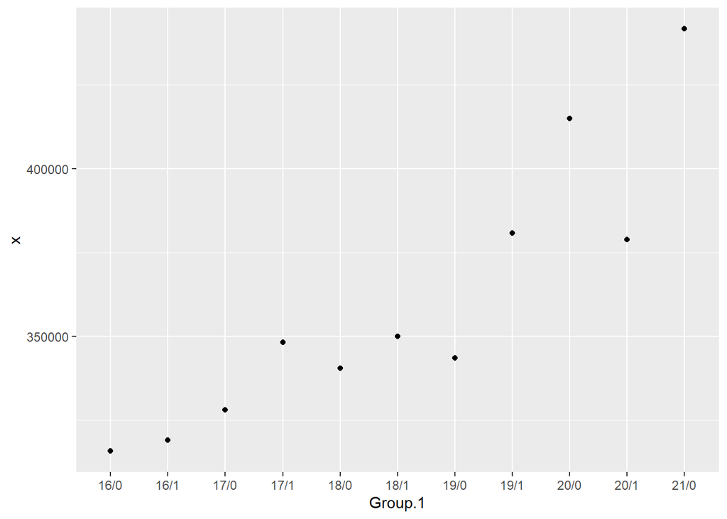

```r
ggplot(data = tdf3,aes(y=x,x=Group.1))+geom_point()
```

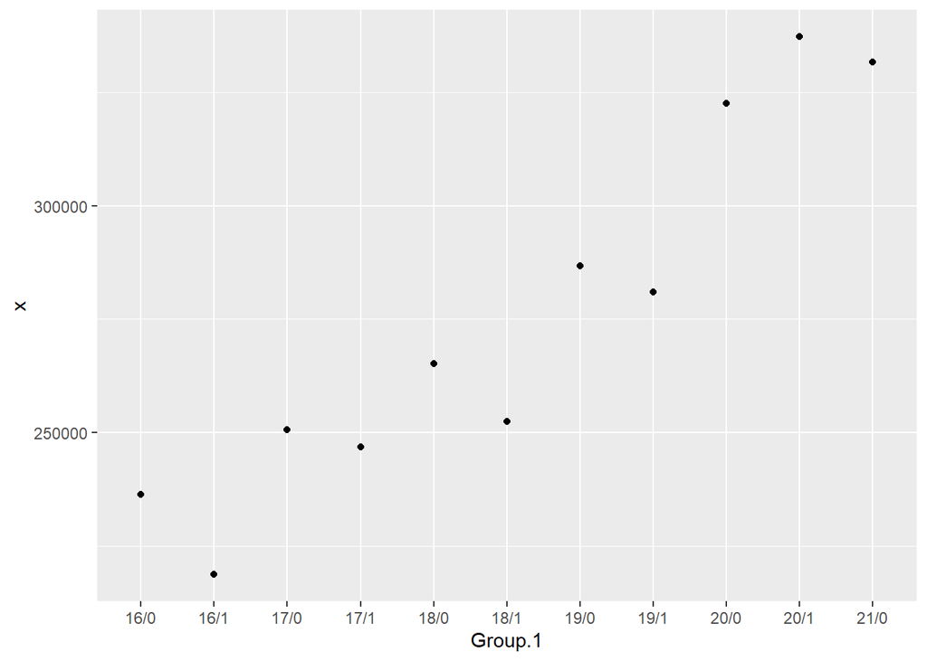

```r
ggplot(data = tdf4,aes(y=x,x=Group.1))+geom_point()
```

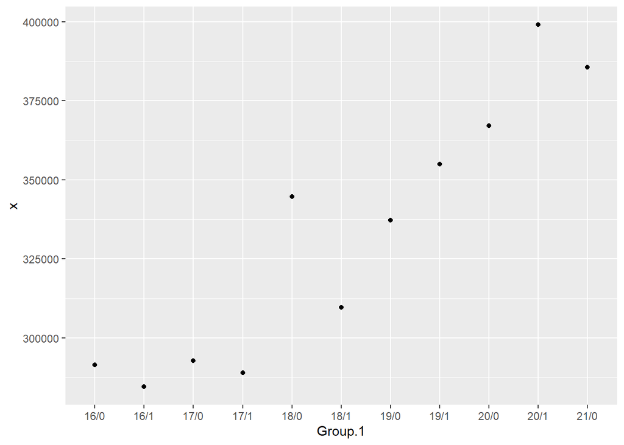

```r
ggplot(data = tdf5,aes(y=x,x=Group.1))+geom_point()
```

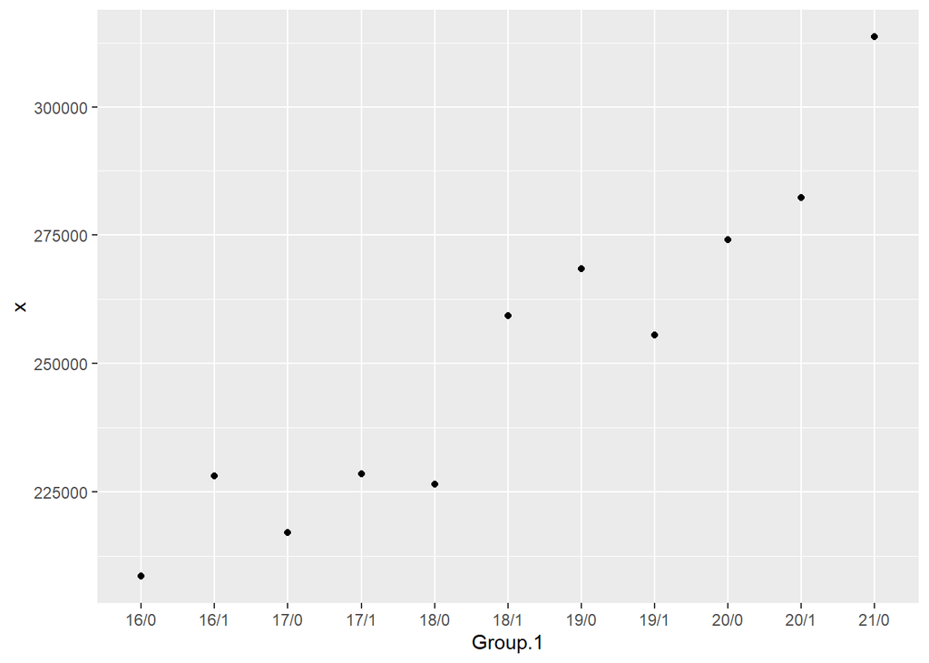

```r
ggplot(data = tdf6,aes(y=x,x=Group.1))+geom_point()
```

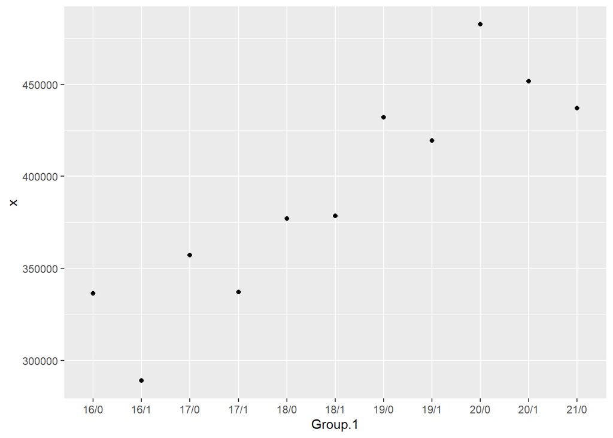

```r
ggplot(data = tdf7,aes(y=x,x=Group.1))+geom_point()
```

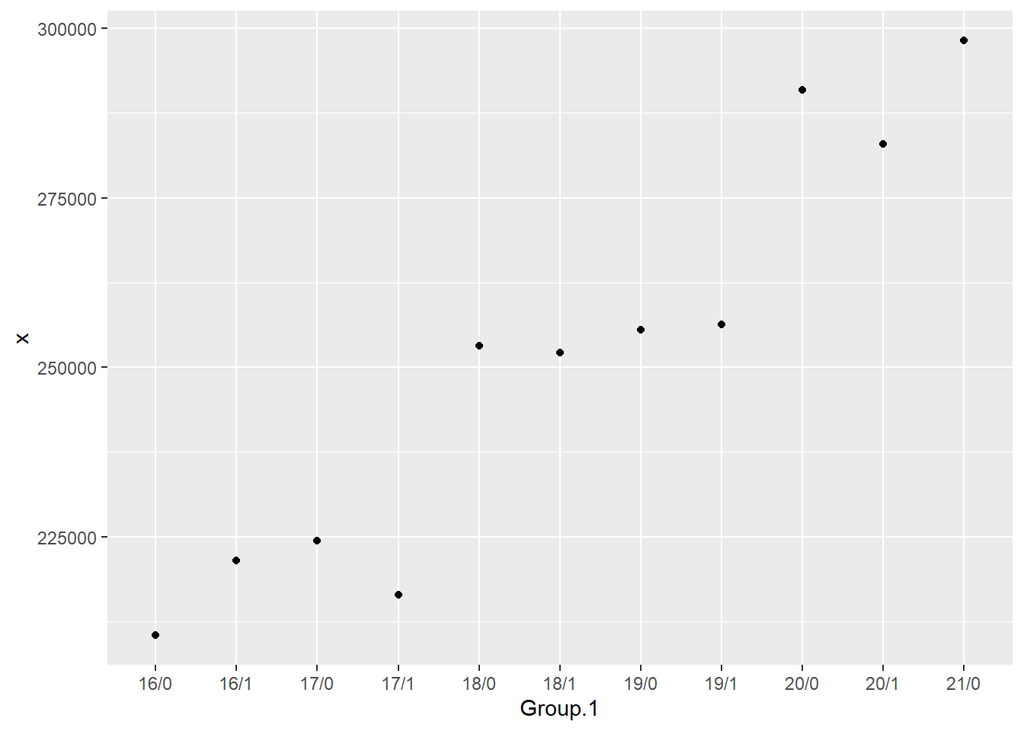

```r
ggplot(data = tdf8,aes(y=x,x=Group.1))+geom_point()
```

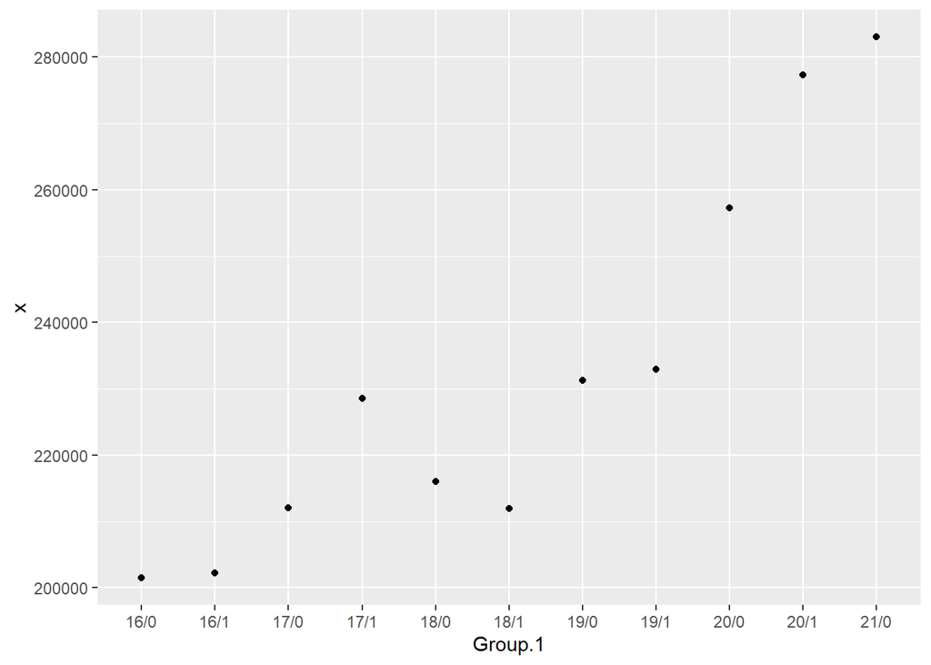

```r
ggplot(data = tdf9,aes(y=x,x=Group.1))+geom_point()
```

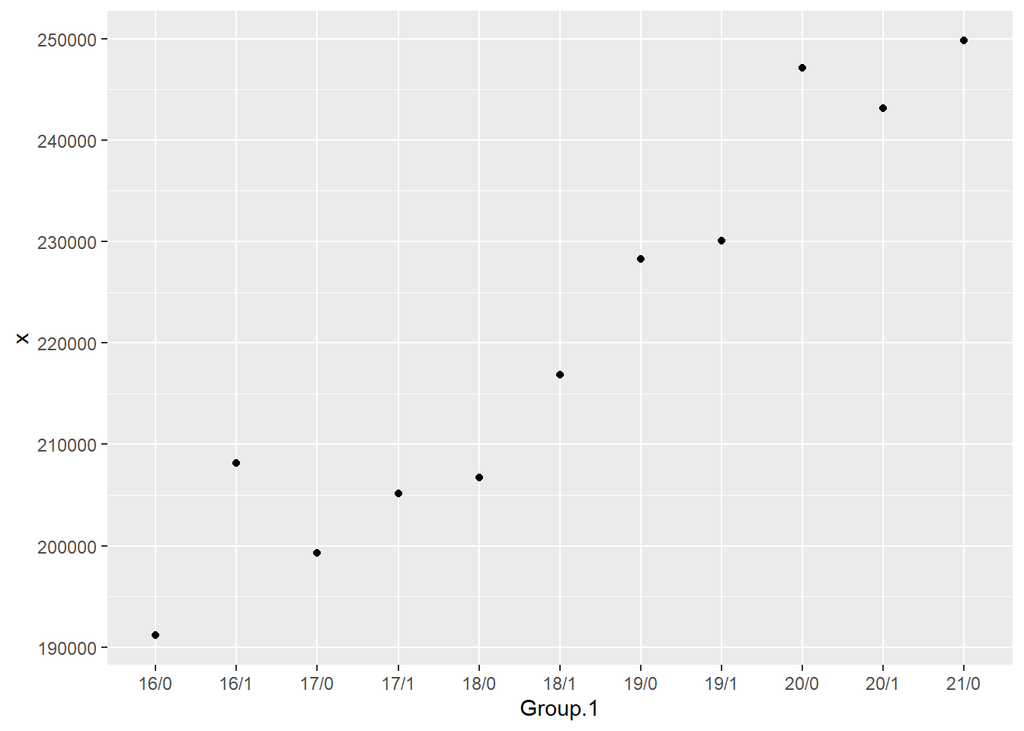

```r
ggplot(data = tdf10,aes(y=x,x=Group.1))+geom_point()
```

به وضوح میبینم که قیمت ها بر حسب سال برای همه مناطق صعودی هستند که نشان دهنده تورم و افزایش قیمت ملک است

# part 3 - Estimation

```r
xx=45.780234113880425
yy=4.865561717882041
tmp =data.frame(clean_df)
dis_from_me = distm(c(yy, xx), cbind(tmp$longitude , tmp$latitude), fun = distHaversine)
tmp$ditance=as.vector(dis_from_me)
tmp=filter(tmp,tmp$price<100000)
tmp=filter(tmp,tmp$ditance<2000)
tmp=filter(tmp,tmp$parkings_count>0)
tmp=filter(tmp,tmp$surface_housing>30)
tmp=filter(tmp,tmp$dis_from_metro<300)

a1=10
a2=1
a3=.1
a4=2
a5=5
tmp=mutate(tmp,point= (tmp$price/mean(tmp$price)*a1)+ (tmp$ditance/mean(tmp$ditance)*a2)+(tmp$parkings_count/mean(tmp$parkings_count)*a3)+(tmp$surface_housing/mean(tmp$surface_housing)*a4)+(tmp$dis_from_metro/mean(tmp$dis_from_metro)*a5) )

print(tmp[tmp$point>=max(tmp$point),])
```

```
##    date_transaction type_purchase type_property rooms_count surface_housing
## 11         19/01/18        ancien   appartement           4              77
##    surface_effective_usable surface_terrain parkings_count price        address
## 11                    76.41               0              1 95000 9 RUE D ALSACE
##        district latitude longitude date_construction price_surface price_room
## 11 Villeurbanne 45.77037  4.870243    03/06/11 11:38      1233.766      23750
##    dis_from_metro  ditance    point
## 11         292.31 1156.765 23.07023
```